# Social Network Analysis R Tutorial Part 8: Triad Census Models

## 3. Example 1: Modeling a Triad Census in Hansell Classroom Friendship Network

Here we consider again the network introduced in SNA tutorial part 5 of strong friendship ties among 13 boys and 14 girls in a sixthgrade classroom, as collected by Hansell (1984). Each student was asked if they liked each other student “a lot”, “some”, or “not much”. Here we consider a strong friendship tie to exist if a student likes another student “a lot.” Also recorded is the sex of each student. The data is in the networkdata package.

```r
rm(list = ls())

#install.packages("ergm", repos="http://www.stat.ucla.edu/~handcock")
#install.packages("ergm.tapered", repos="http://www.stat.ucla.edu/~handcock")
#or devtools::install_github("statnet/ergm.tapered")
#devtools::install_github('statnet/ergm', ref='tapered')
#install.packages("ergm.tapered")

library(networkdata)
library(network)
library(ergm)
library(sna)
library(ergm.tapered)
```

### 3.1 Fit a triad census model using ergm.tapered. Include a term for homophily by sex.

```r
data("hansell")
help(hansell)
table(hansell %v% "sex")
```

```
female   male
    14     13
```

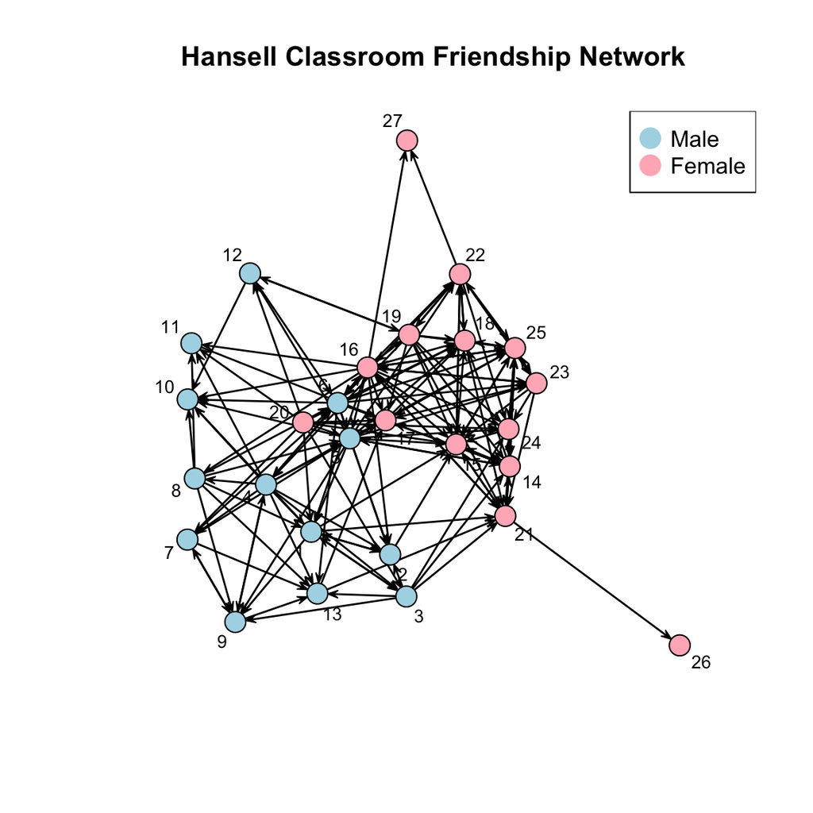

```r
sex_attr <- hansell %v% "sex"
vertex_colors <- ifelse(sex_attr == "male", "lightblue", "lightpink")

set.seed(42)
plot(hansell,
     vertex.col = vertex_colors,
     main = "Hansell Classroom Friendship Network",
     vertex.cex = 2,
     label = 1:network.size(hansell),
     label.cex = 0.8)

legend("topright",
       legend = c("Male", "Female"),
       col = c("lightblue", "lightpink"),
       pch = 19,
       pt.cex = 2)
```

```r
triad.census(hansell)
```

```
     003 012 102 021D 021U 021C 111D 111U 030T 030C 201 120D 120U 120C 210 300
[1,] 771 982 248  234  115  150   68   97  126    2  13   32   32   20  28   7
```

```r
triad.census(hansell)[2]
```

```
[1] 982
```

```r
set.seed(42)
fit1a <- ergm.tapered(hansell ~ edges + nodematch("sex") + triadcensus(c(1:8, 10:15)),
                      control = control.ergm.tapered(seed = 123))
summary(fit1a)
```

```
 Results:

                 Estimate Std. Error MCMC % z value Pr(>|z|)
edges            -12.1760     5.8895      0  -2.067 0.038694 *
nodematch.sex      0.9125     0.2650      0   3.444 0.000573 ***
triadcensus.012    0.3406     0.2335      0   1.459 0.144605
triadcensus.102    0.8071     0.4695      0   1.719 0.085617 .
triadcensus.021D   0.8390     0.4703      0   1.784 0.074442 .
triadcensus.021U   0.8016     0.4650      0   1.724 0.084755 .
triadcensus.021C   0.7018     0.4805      0   1.461 0.144125
triadcensus.111D   1.0480     0.7126      0   1.471 0.141387
triadcensus.111U   1.1019     0.7076      0   1.557 0.119436
triadcensus.030T   1.4666     0.7089      0   2.069 0.038570 *
triadcensus.201    1.4035     0.9545      0   1.470 0.141448
triadcensus.120D   1.8346     0.9378      0   1.956 0.050426 .
triadcensus.120U   1.9169     0.9358      0   2.049 0.040508 *
triadcensus.120C   1.5512     0.9756      0   1.590 0.111848
triadcensus.210    2.3795     1.1754      0   2.024 0.042932 *
triadcensus.300    3.5463     1.4308      0   2.478 0.013195 *
---
Signif. codes:  0 '***' 0.001 '**' 0.01 '*' 0.05 '.' 0.1 ' ' 1
The estimated tapering scaling factor is 2.

     Null Deviance: 973.2  on 702  degrees of freedom
 Residual Deviance: 653.1  on 686  degrees of freedom

AIC: 685.1  BIC: 758  (Smaller is better. MC Std. Err. = 0)
```

```r
coef_table1a <- data.frame(
  Coefficient = round(coef(fit1a), 3),
  SE = round(summary(fit1a)$coefficients[, "Std. Error"], 3),
  OR = round(exp(coef(fit1a)), 3),
  p_value = round(summary(fit1a)$coefficients[, "Pr(>|z|)"], 4)
)

print(coef_table1a)
```

```
                 Coefficient    SE     OR p_value
edges                -12.176 5.889  0.000  0.0387
nodematch.sex          0.913 0.265  2.491  0.0006
triadcensus.012        0.341 0.233  1.406  0.1446
triadcensus.102        0.807 0.470  2.241  0.0856
triadcensus.021D       0.839 0.470  2.314  0.0744
triadcensus.021U       0.802 0.465  2.229  0.0848
triadcensus.021C       0.702 0.481  2.017  0.1441
triadcensus.111D       1.048 0.713  2.852  0.1414
triadcensus.111U       1.102 0.708  3.010  0.1194
triadcensus.030T       1.467 0.709  4.334  0.0386
triadcensus.201        1.403 0.954  4.069  0.1414
triadcensus.120D       1.835 0.938  6.262  0.0504
triadcensus.120U       1.917 0.936  6.800  0.0405
triadcensus.120C       1.551 0.976  4.717  0.1118
triadcensus.210        2.379 1.175 10.799  0.0429
triadcensus.300        3.546 1.431 34.684  0.0132
```

```r
plogis(coef(fit1a)["edges"] + coef(fit1a)["nodematch.sex"])
```

```
       edges
1.283287e-05
```